# STT2860: Final Presentation

May 05, 2022 @ 12:47 PM

### **Packages Used**

I used tidyverse for data manipulations.

```r
library(tidyverse)
```

I used mapdata to see if global trends existed in the data.

```r
library(mapdata)
```

### **Environment Data - UNdata**

I found data from the UNdata website (https://data.un.org/). The dataset was last updated November 2021.

**Variables in the Dataset:**

- `CO2 emission estimates`: country for which the CO2 emission is being estimated
- `Year`: year of the CO2 estimate
- `Series`: Total CO2 Emissions or CO2 Emissions per capita
- `Value`: The number in thousand metric tons of CO2 or the number in metric tons of CO2

### **Data Manipulations**

- `pivot_wider()`: Manipulated the data so that the total emissions and emission per capita were in different columns
- `rename()`: Renamed the columns to better signify data and into more R friendly format
- `filter()`: Filtered the data so I only had data from the most recent year: 2017
- `transmute()` & `case_when()`: Changed the names of countries so that the would match the names in mapdata

### **CO2 Total Emissions**

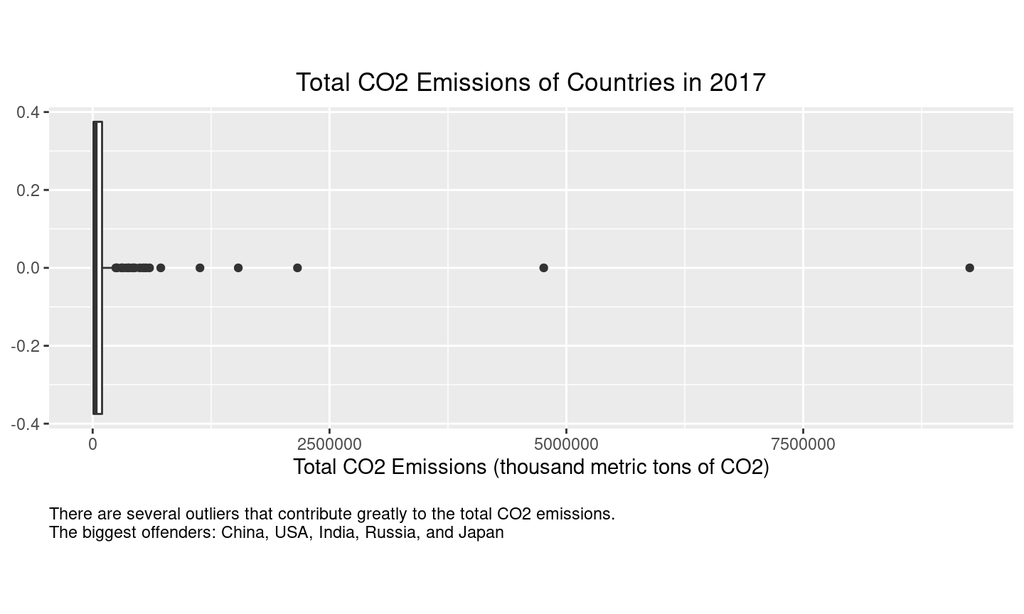

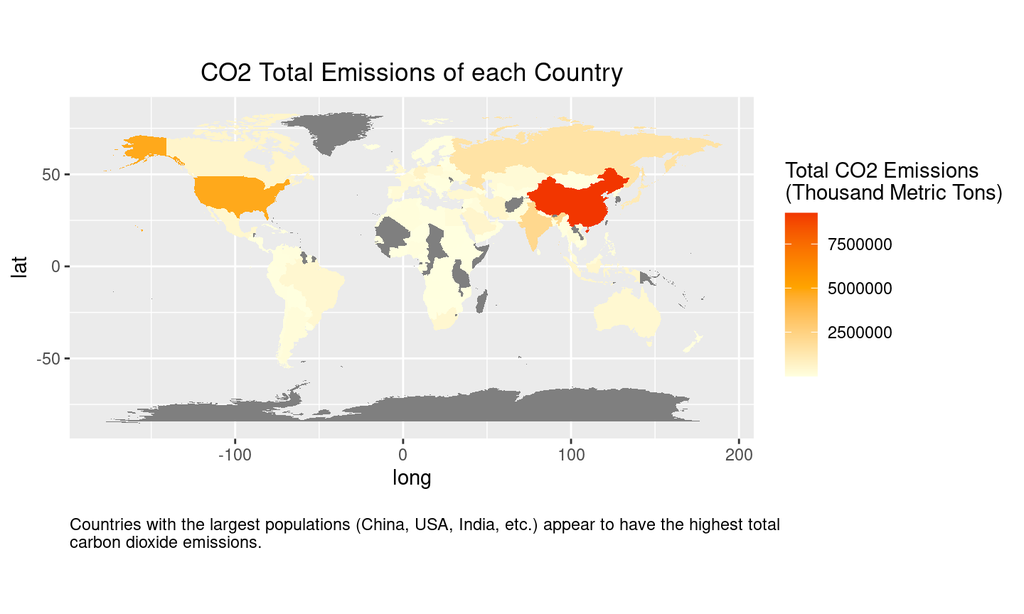

What would happen if their populations were taken into account?

### **CO2 Emissions per capita**

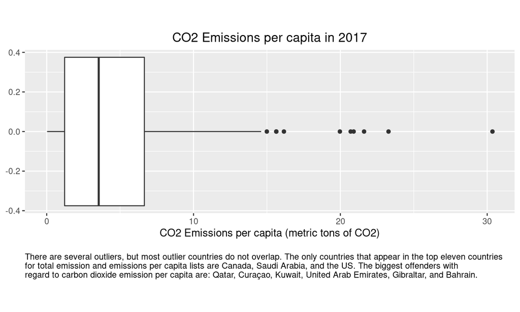

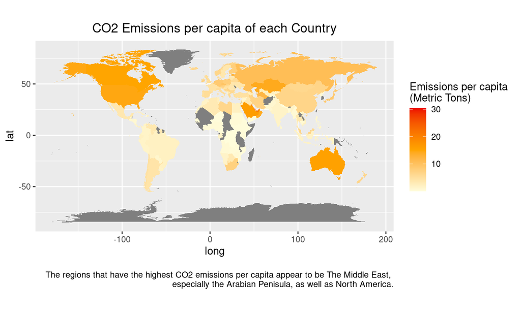

### **Other Lines of Inquiry**

- How have carbon dioxide emissions changed overtime?
- Is there correlation between 1st/2nd/3rd world countries and CO2 emissions?
- How has carbon dioxide emissions changed since COVID?